# R Notebook

# **PART 2: Data Exploration**

```r
# Reading the csv file
Data <- read.csv("Data/clean_dataset.csv")
```

```r
#Viewing data
Data
```

| Number_of_Vehicles | Accident_Date | Accident_Day | Time_24hr | First_Road_Class | Road_Surface | Lighting_Conditions | Weather_Conditions | Type_of_Vehicle | Casualty_Class | Casualty_Severity | Sex_of_Casualty | Age_of_Casualty | Year |
| --- | --- | --- | --- | --- | --- | --- | --- | --- | --- | --- | --- | --- | --- |
| 2 | 2017-01-01 | Sunday | 21:20 | U | Wet/Damp | Darkness: street lights present and lit | Raining without high winds | Car | Vehicle or pillion passenger | Serious | Female | 16 | 2017 |
| 2 | 2017-01-04 | Wednesday | 15:00 | U | Dry | Daylight: street lights present | Fine without high winds | Car | Pedestrian | Serious | Female | 67 | 2017 |
| 2 | 2017-01-05 | Thursday | 07:32 | A | Wet/Damp | Darkness: street lights present and lit | Fine without high winds | Car | Driver or rider | Slight | Male | 56 | 2017 |
| 2 | 2017-01-05 | Thursday | 09:30 | A | Wet/Damp | Daylight: street lights present | Fine without high winds | Motorcycle over 125cc and up to 500cc | Driver or rider | Fatal | Male | 20 | 2017 |
| 2 | 2017-01-14 | Saturday | 09:09 | U | Frost/Ice | Daylight: street lights present | Fine without high winds | Car | Driver or rider | Slight | Male | 46 | 2017 |
| 1 | 2017-01-15 | Sunday | 16:59 | U | Wet/Damp | Darkness: street lights present and lit | Fine without high winds | Car | Pedestrian | Slight | Male | NA | 2017 |
| 1 | 2017-01-16 | Monday | 10:59 | A | Wet/Damp | Daylight: street lights present | Fine without high winds | Car | Pedestrian | Slight | Female | 25 | 2017 |
| 3 | 2017-01-19 | Thursday | 18:49 | B | Dry | Darkness: street lights present and lit | Fine without high winds | Car | Driver or rider | Slight | Female | 50 | 2017 |
| 1 | 2017-01-20 | Friday | 14:08 | U | Dry | Daylight: street lights present | Fine without high winds | Car | Pedestrian | Slight | Female | 64 | 2017 |
| 1 | 2017-01-22 | Sunday | 13:25 | A | Wet/Damp | Daylight: street lights present | Fine without high winds | Car | Driver or rider | Slight | Female | 22 | 2017 |

[output cut: 990 more lines]

#### **Expected Insights:** Generally we relate accident with weather because they significantly influence road surface conditions, which in turn affect driving safety. And gender is also important beacuse according to research have shown differences in risk-taking behaviors and reaction times between genders, which can affect accident outcomes.

#### **Task:** Let’s first see the differences in accident by weather and gender.

```r
# Load necessary libraries
library(dplyr)
library(tidyr)
library(ggplot2)
library(stringr)  # Load stringr package for str_wrap function

# Filter data to include only drivers/riders
driver_rider_data <- Data %>%
  filter(Casualty_Class == "Driver or rider")

# Summarize accidents by weather condition and gender
gender_weather_summary <- driver_rider_data %>%
  filter(!is.na(Sex_of_Casualty) & !is.na(Weather_Conditions)) %>%
  group_by(Weather_Conditions, Sex_of_Casualty) %>%
  summarize(Count = n(), .groups = 'drop')

# Use pivot_wider to reshape the data
gender_diff <- gender_weather_summary %>%
  pivot_wider(names_from = Sex_of_Casualty, values_from = Count, values_fill = list(Count = 0)) %>%
  mutate(Difference = Male - Female) %>%
  filter(Difference > 0)

# Print the results
print(gender_diff)
```

| Weather_Conditions | Female | Male | Difference |
| --- | --- | --- | --- |
| Fine with high winds | 4 | 7 | 3 |
| Fine without high winds | 303 | 691 | 388 |
| Fog or mist – if hazard | 3 | 6 | 3 |
| Raining with high winds | 17 | 26 | 9 |
| Raining without high winds | 52 | 83 | 31 |
| Snowing with high winds | 0 | 2 | 2 |
| Snowing without high winds | 5 | 8 | 3 |

```r
NA
NA
```

#### **Observation:**

```r
# Print the results of Observation
gender_diff %>%
  mutate(Description = paste("Male drivers have", Difference, "more accidents than females when weather is", Weather_Conditions)) %>%
  select(Description) %>%
  print()
```

| Description |
| --- |
| Male drivers have 3 more accidents than females when weather is Fine with high winds |
| Male drivers have 388 more accidents than females when weather is Fine without high winds |
| Male drivers have 3 more accidents than females when weather is Fog or mist – if hazard |
| Male drivers have 9 more accidents than females when weather is Raining with high winds |
| Male drivers have 31 more accidents than females when weather is Raining without high winds |
| Male drivers have 2 more accidents than females when weather is Snowing with high winds |
| Male drivers have 3 more accidents than females when weather is Snowing without high winds |

#### **Observation:**

#### * The difference in accident between gender is highest when weather is fine without high wind.

#### **Task:** Lets visualize in bar to see difference in accident count of male and female in different weather.

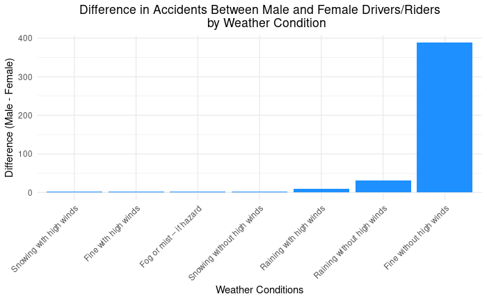

```r
# Calculate order based on Difference
weather_order <- gender_diff %>%
  arrange(Difference) %>%
  pull(Weather_Conditions)

# Plot with ordered Weather Conditionss
ggplot(gender_diff, aes(x = factor(Weather_Conditions, levels = weather_order), y = Difference)) +
  geom_bar(stat = "identity", fill = "dodgerblue") +
  labs(
    title = "Difference in Accidents Between Male and Female Drivers/Riders
    by Weather Condition",
    x = "Weather Conditions",
    y = "Difference (Male - Female)"
  ) +
  theme_minimal() +
  theme(
    axis.text.x = element_text(angle = 45, hjust = 1),
    plot.title = element_text(hjust = 0.5)  # Center the title horizontally
  )
```

```r
NA
NA
```

#### **Actual Insights:** Our expected insights and actual insights were quiet similiar, the male tend to be more riskier than female and lead to accident. In the fine weather the males tend to speed up or not care and have more accidents.

#### **Task:** Since we have time as well we can see the accident trend and casualty according to year.

```r
# Ensure Accident_Date is of Date type and extract the year
Data <- Data %>%
  mutate(Accident_Date = as.Date(Accident_Date, format = "%Y-%m-%d"),
         Year = format(Accident_Date, "%Y"))

# Summarize the number of casualties per year
casualties_over_time <- Data %>%
  group_by(Year) %>%
  summarize(Casualties = n(), .groups = 'drop')

# Print summary
print(casualties_over_time)
```

| Year | Casualties |
| --- | --- |
| 2014 | 623 |
| 2015 | 556 |
| 2016 | 554 |
| 2017 | 336 |

```r
NA
```

```r
# Identify the year with the highest number of casualties
max_casualties_year <- casualties_over_time %>%
  arrange(desc(Casualties)) %>%
  slice(1)

# Print the year with the highest casualties
print(max_casualties_year)
```

| Year | Casualties |
| --- | --- |
| 2014 | 623 |

```r
NA
```

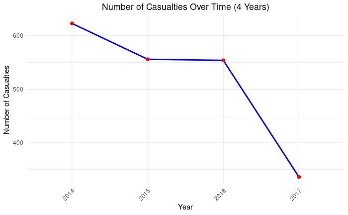

```r
# Ensure the Year column is a factor to preserve the order in the plot
casualties_over_time <- casualties_over_time %>%
  mutate(Year = factor(Year, levels = unique(Year)))

# Plot the trend of casualties over three years
ggplot(casualties_over_time, aes(x = Year, y = Casualties, group = 1)) +
  geom_line(color = "blue", size = 1) +
  geom_point(color = "red", size = 2) +
  labs(title = "Number of Casualties Over Time (4 Years)", x = "Year", y = "Number of Casualties") +
  theme_minimal() +
  theme(
    plot.title = element_text(hjust = 0.5),
    axis.text.x = element_text(angle = 45, hjust = 1)
  )
```

```r
NA
NA
```

#### **Observation:** From the observation we can see that there is sharp decrease in the number of casualties with time

#### **Inference:** This may be due to safety and awarneess or lighting conditions in road.

#### **Task:** Let’s check the relation between light conditions and accidnet severity

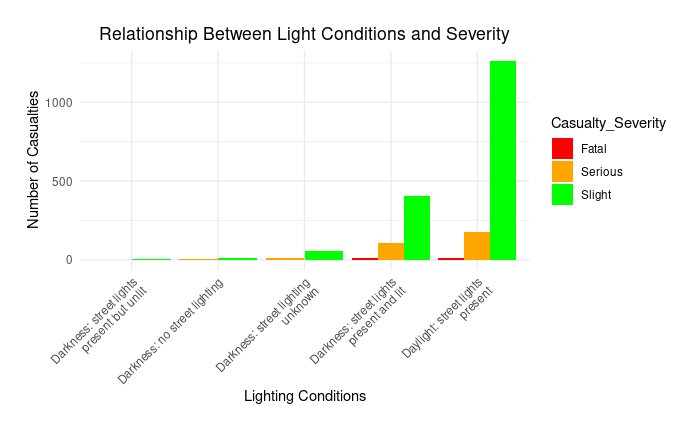

```r
# Calculate total counts for each Lighting Condition
lighting_order <- Data %>%
  group_by(Lighting_Conditions) %>%
  summarise(total_count = n(), .groups = 'drop') %>%
  arrange(total_count) %>%
  pull(Lighting_Conditions)

# Plot with reordered Lighting Conditions based on total counts
light_severity_plot <- Data %>%
  group_by(Lighting_Conditions, Casualty_Severity) %>%
  summarise(count = n(), .groups = 'drop') %>%
  mutate(Lighting_Conditions = factor(Lighting_Conditions, levels = lighting_order)) %>%  # Reorder the factor levels
  ggplot(aes(x = Lighting_Conditions, y = count, fill = Casualty_Severity)) +
  geom_bar(stat = "identity", position = "dodge") +
  labs(
    title = "Relationship Between Light Conditions and Severity",
    x = "Lighting Conditions",
    y = "Number of Casualties"
  ) +
  scale_x_discrete(labels = function(x) str_wrap(x, width = 30)) +  # Wrap the x-axis labels
  scale_fill_manual(
    values = c(
      "Fatal" = "red",    # Set "Fatal" to red
      "Serious" = "orange",  # Set "Serious" to orange
      "Slight" = "green"    # Set "Slight" to green
    )
  ) +
  theme_minimal() +
  theme(
    axis.text.x = element_text(angle = 45, hjust = 1),  # Rotate x-axis labelss
    plot.title = element_text(hjust = 0.5),  # Center the title
    plot.margin = margin(t = 20, r = 20, b = 20, l = 20)  # Adjust plot margins
  )

print(light_severity_plot)
```

```r
NA
NA
```

#### **Observation:** In graph we can see that in Day and where street light is lit the number of causalty is high.

#### **Insights:** From observed we can conclude that if there is saftey they tend to do carlessness specially male which comes from the casualty according to gender as well.

# **Task:** Seeing the number of vechicle involded in the accident

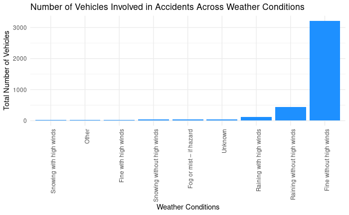

```r
# Aggregate data to count the number of vehicles per weather condition
vehicle_count <- Data %>%
  group_by(Weather_Conditions) %>%
  summarise(total_vehicles = sum(Number_of_Vehicles, na.rm = TRUE))

# Order weather conditions by total number of vehicles involved
vehicle_count <- vehicle_count %>%
  arrange(total_vehicles) %>%
  mutate(Weather_Conditions = factor(Weather_Conditions, levels = Weather_Conditions))

# Plotting the grouped bar chart
ggplot(vehicle_count, aes(x = Weather_Conditions, y = total_vehicles, fill = Weather_Conditions)) +
  geom_bar(stat = "identity", position = "dodge", fill="dodgerblue") +
  labs(
    title = "Number of Vehicles Involved in Accidents Across Weather Conditions",
    x = "Weather Conditions",
    y = "Total Number of Vehicles"
  ) +
  theme_minimal() +
  theme(
    axis.text.x = element_text(angle = 90, hjust = 1),  # Rotate x-axis labels for better readability
    legend.position = "none"
  )
```

```r
NA
NA
NA
NA
```

#### **Observation:** From graph we can see that the number of vechicle involved in accident in fine weather very high compared to harsh weather.

### **Final Insight:**

#### * From all observation, we know that the accident mainly happens where conditions of lighting is presnet and lit and weather is good. We can draw conclusion that people specially male tend to be careless regarding the saftey drive.

#### * Whereas in harsh wetaher and absent lighting condition people are cautious and have less accident.

#### Additional Visualization

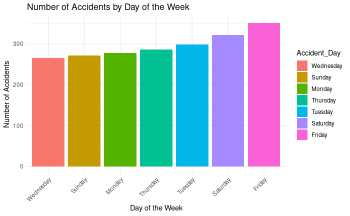

```r
# Load necessary libraries
library(dplyr)
library(ggplot2)
library(forcats)  # For reordering factor levels

# Assuming your dataset is in a data frame called 'data'
# Summarize the number of accidents by day of the week
accident_summary <- data %>%
  group_by(Accident_Day) %>%
  summarize(Number_of_Accidents = n())

# Reorder 'Accident_Day' based on the number of accidents
accident_summary <- accident_summary %>%
  mutate(Accident_Day = fct_reorder(Accident_Day, Number_of_Accidents))

# Create a bar plot with reordered days
ggplot(accident_summary, aes(x = Accident_Day, y = Number_of_Accidents, fill = Accident_Day)) +
  geom_bar(stat = "identity") +
  labs(title = "Number of Accidents by Day of the Week",
       x = "Day of the Week",
       y = "Number of Accidents") +
  theme_minimal() +
  theme(axis.text.x = element_text(angle = 45, hjust = 1)) +
  scale_fill_manual(values = scales::hue_pal()(length(unique(accident_summary$Accident_Day))))
```

#### **Observation:** As shown in graph Friday is the day where most accident occured.

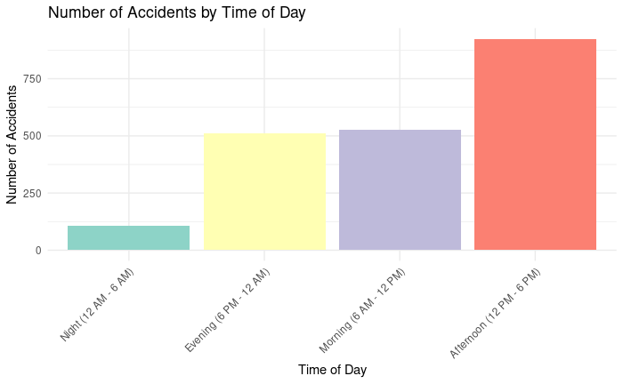

```r
# Assuming your dataset is in a data frame called 'data'
# Create a temporary transformation for time periods
accident_summary <- data %>%
  mutate(
    Hour = as.numeric(substr(Time_24hr, 1, 2))
  ) %>%
  mutate(
    Time_Period = case_when(
      Hour >= 6 & Hour < 12  ~ "Morning (6 AM - 12 PM)",
      Hour >= 12 & Hour < 18 ~ "Afternoon (12 PM - 6 PM)",
      Hour >= 18 & Hour < 24 ~ "Evening (6 PM - 12 AM)",
      TRUE                   ~ "Night (12 AM - 6 AM)"
    )
  ) %>%
  group_by(Time_Period) %>%
  summarize(Number_of_Accidents = n()) %>%
  ungroup()

# Reorder time periods based on the number of accidents in ascending order
accident_summary <- accident_summary %>%
  mutate(Time_Period = factor(Time_Period,
                              levels = accident_summary$Time_Period[order(accident_summary$Number_of_Accidents)]))

# Create a bar plot with reordered time periods
ggplot(accident_summary, aes(x = Time_Period, y = Number_of_Accidents, fill = Time_Period)) +
  geom_bar(stat = "identity") +
  labs(title = "Number of Accidents by Time of Day",
       x = "Time of Day",
       y = "Number of Accidents") +
  theme_minimal() +
  theme(axis.text.x = element_text(angle = 45, hjust = 1)) +
  scale_fill_brewer(palette = "Set3") +
  guides(fill = FALSE)
```

```r
NA
NA
```

#### **Observation:** The time where most accident occured is Afternoon and least is Night.

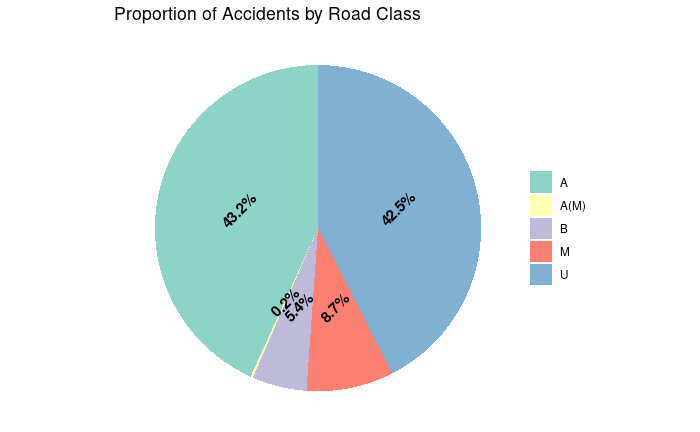

```r
# Assuming your dataset is in a data frame called 'data'
# Summarize the number of accidents by road class
accident_summary <- data %>%
  group_by(First_Road_Class) %>%
  summarize(Number_of_Accidents = n()) %>%
  ungroup()

# Calculate percentages
accident_summary <- accident_summary %>%
  mutate(Percent = Number_of_Accidents / sum(Number_of_Accidents) * 100)

# Create a pie chart with slanted percentages
ggplot(accident_summary, aes(x = "", y = Number_of_Accidents, fill = First_Road_Class)) +
  geom_bar(stat = "identity", width = 1) +
  geom_text(aes(label = paste0(round(Percent, 1), "%")),
            position = position_stack(vjust = 0.5),
            size = 4, color = "black", fontface = "bold",
            angle = 45, hjust = 0.5) +  # Adjust angle and hjust for slanting
  coord_polar("y", start = 0) +
  labs(title = "Proportion of Accidents by Road Class",
       x = NULL,
       y = NULL) +
  theme_void() +  # Remove all axis and background
  scale_fill_brewer(palette = "Set3") +  # Choose a color palette
  theme(legend.title = element_blank(),  # Remove legend title
        legend.position = "right")  # Position legend to the right
```

#### **Observation:** The highest percentage of the accident is in road type A and U.